#### Practical Machine Learning Project

#### Introduction

Using devices such as Jawbone Up, Nike FuelBand, and Fitbit it is now possible to collect a large amount of data about personal activity relatively inexpensively. These type of devices are part of the quantified self movement - a group of enthusiasts who take measurements about themselves regularly to improve their health, to find patterns in their behavior, or because they are tech geeks. One thing that people regularly do is quantify how much of a particular activity they do, but they rarely quantify how well they do it. In this project, your goal will be to use data from accelerometers on the belt, forearm, arm, and dumbell of 6 participants. They were asked to perform barbell lifts correctly and incorrectly in 5 different ways. More information is available from the website here

#### Data

Set directory and download the data At the same time, remove the NAs

```r
setwd("C:/Users/Elizabeth/Desktop/Datascience/Coursera/Machine_Learning/Assignment")
getwd()
```

```
## [1] "C:/Users/Elizabeth/Desktop/Datascience/Coursera/Machine_Learning/Assignment"
```

```r
train <- read.csv("C:/Users/Elizabeth/Desktop/Datascience/Coursera/Machine_Learning/Assignment/pml-training.csv", na.strings=c("NA",""))

test <- read.csv("C:/Users/Elizabeth/Desktop/Datascience/Coursera/Machine_Learning/Assignment/pml-testing.csv", na.strings=c("NA",""))
```

#### Load the libraries

```r
library(caret)
library(kernlab)
library(rpart)
library(randomForest)
```

#### Set seed

```r
set.seed(1235)
```

##### Remove columns with missing values and non-exercise variables to build a better model

```r
train<-train[,colSums(is.na(train)) == 0]
test <-test[,colSums(is.na(test)) == 0]
train   <-train[,-c(1:7)]
test <-test[,-c(1:7)]
```

###### Partion the data into training and validation subsets

Subset the training data into 70% training and 30% for validation. Keep the test data aside so that it is used to predict the final model

```r
inTrain <- createDataPartition(y=train$classe, p = 0.7, list = FALSE)
training <- train[inTrain ,]
validation <- train[-inTrain ,]
```

###### dimension of the data

```r
dim(training)
```

```
## [1] 13737    53
```

```r
dim(validation)
```

```
## [1] 5885   53
```

After preprocessing and cleaning the data, the training data has 13737 records and 53 variables. Validation dataset has 5885 records and 53 variables

###### visualize the data

```r
table(training$classe)
```

```
##
##    A    B    C    D    E
## 3906 2658 2396 2252 2525
```

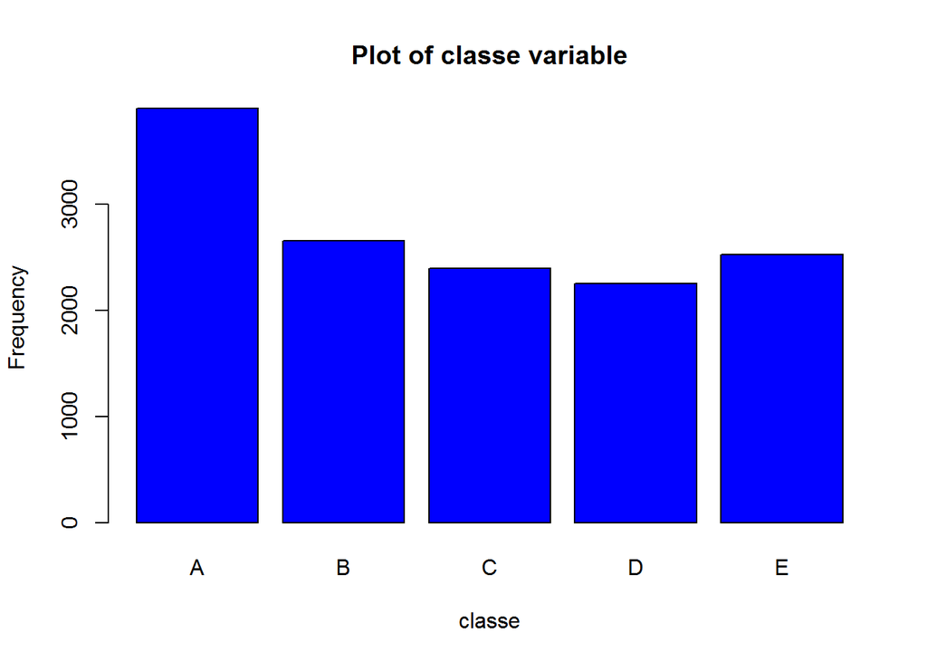

```r
plot(training$classe, col="blue", main="Plot of classe variable", xlab="classe", ylab="Frequency")
```

The table shows the number of records in each of the classes A, B, C, D, E

# Fitting the models